# Computer Lab 1

Michael Alfaro

2/28/2022

# Simulating genetic drift forward in time

#### Computer Lab 1 for EEB 200B

Recall that genetic drift is essentially binomial sampling from one generation to the next. Put another way, given the allele frequency in the present generation, the allele frequency in the next generation follows a binomial distribution.

R is equipped to simulate binomial random variables quite easily. To simulate from the binomial distribution, use the `rbinom` function.

Read about R’s implementation of the binomial distribution using the following command:

```r
?rbinom
```

The `rbinom` function takes 3 arguments: `rbinom(n, size, prob)`

`n` is the number of random variables that you wish to draw. For example, if you were simulating 10 independent SNPs at one time, you could set n=10. If you’re only simulating 1 SNP, set n=1.

Note, this can get confusing. Previously, when we spoke of the binomial distribution, n was the “size” (i.e. The maximum number of successes). In R, it is the number of random values drawn.

`size` is the maximum value that any particular random variable can take on. When simulating drift, this value will be the number of chromosomes in the population (twice the number of individuals for a diploid population). In other arenas, this argument is sometimes called “n”.

`prob` is the probability of success. What is a success? Well, that’s in the eye of the beholder. For coin flips, a success could be the coin coming up “heads”. When simulating drift, a “success” could be the allele being transmitted. The probability of success will be the allele frequency (not count) in the previous generation. This is a probability so it must range from 0 to 1.

The `rbinom` command will return a vector of length n with random draws from the binomial distribution.

#### Example:

> rbinom(3, 10, 0.1) [1] 3 0 1

This means that we’ve drawn 3 random variables from a binomial distribution. In the first draw, we saw 3 out of 10 successes. In the second draw, we saw 0 out of 10 successes. In the third draw, we saw 1 out of 10 successes.

### EXERCISE 1.

What is the expected number of successes in a sample of size 10 from the binomial distribution with probability of success p=0.1?

First, figure this out analytically based on the formulas from class.

*The expected number of successes is 0.1 x 10 = 1*

Second, write a simulation in R to confirm this.

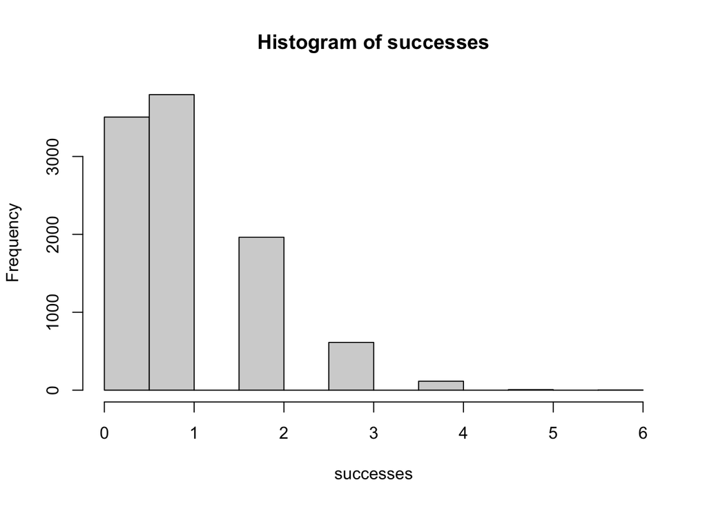

```r
set.seed(1)
successes <- rbinom(n = 10000, size = 10, p = 0.1)
hist(successes)
```

```r
mn <- mean(successes)
mn
```

```
## [1] 1.0066
```

*I ran the simulation 10,000 times, and the mean number of successes was 1.0066 (i.e. basically 1). I conclude that the expected number of successes in a sample of size 10 from the binomial distribution with probability of success p = 0.1 is 1. This makes sense: we’re sampling 10 times, and the probability of success each time is 1/10, so we should expect to be successful on average one time out of every 10 samples.*

Now, let’s use the `rbinom` function in R to simulate genetic drift.

Let `p` be the allele frequency in the present generation, `N` is the population size. `N` can be the number of diploid individuals, or the number of chromosomes in the population. Either will work, as long as you are consistent. For the purposes of this lab exercise, let’s define `N` to be the number of diploid individuals in the population. Thus, there would be `2N` chromosomes in the population.

Then,

> p<-0.1 # the frequency of the allele that we care about is 0.1 in this generation N<-10 # 10 diploid individuals in the population (which means there will be 2N chromosomes) count <- rbinom(1, 2*N, p) count [1] 3 count/(2*N) [1] 0.15

Thus, the allele changed in frequency from 0.1 to 0.15 in a single generation! this is pretty boring. Let’s do a real simulation with 1) more than 1 SNP at a time, and 2) more than 1 generation at a time!

### EXERCISE 2.

Write a function in R that will simulate `t` generations of genetic drift for `L` independent SNPs. Keep track of the allele frequencies of each of the `L` SNPs in each of the `t` generations. All SNPs should start in the initial generation at frequency `p`.

Hint: Start by initializing a matrix to keep track of the frequencies each generation:

```r
t <- 5 # number of generations (I changed this from T to t to avoid overwriting R's `TRUE`.)
L <- 3 # number of independent SNPs
freqs <- matrix(nrow = t, ncol = L) # now initialize a matrix of the allele freqs each generation. Let each row be a generation, and each column be an SNP.
freqs
```

```
##      [,1] [,2] [,3]
## [1,]   NA   NA   NA
## [2,]   NA   NA   NA
## [3,]   NA   NA   NA
## [4,]   NA   NA   NA
## [5,]   NA   NA   NA
```

Another hint: Consider initializing the first row of this matrix with the initial allele frequency (`p`).

```r
freqs[1,] <- 0.1
```

Then, write a loop that will iterate through each generation and will perform the binomial sampling.

```r
driftFunction <- function(t = 5, L = 3, p = 0.1, N = 100){
  # Initialize the matrix
  freqs <- matrix(nrow = t, ncol = L)
  freqs[1,] <- rep(p, L)

  # Define number of alleles, since N is number of diploid individuals
  nalleles <- 2*N

  # Iterate through each generation
  for(i in 2:nrow(freqs)){
    prevAlleleFreqs <- freqs[i-1,] # get the previous row's allele frequencies

    # Compute the allele counts in this generation, based on the previous generation's frequencies
    newAlleleCounts <- rbinom(n = L, size = nalleles, p = prevAlleleFreqs)

    # Divide by total number of alleles to obtain frequencies
    newAlleleFreqs <- newAlleleCounts/nalleles

    # Put the new allele frequencies into the `freqs` table
    freqs[i,] <- newAlleleFreqs
  }
  return(freqs)
}
```

### EXERCISE 3.

Use the function that you just wrote to simulate drift with the following parameters: `N`=100 (`N` is the number of diploids, so there should be `2N`=200 chromosomes) `L`=1000 `t`=10000 `p`=0.1

```r
set.seed(2)
driftResults <- driftFunction(N = 100, L = 1000, t = 10000, p = 0.1)
```

Now, let’s compute some things:

1. How many of the 1000 SNP are at frequency 0 at the end of the simulation (in generation 10000)?

```r
ngone <- sum(tail(driftResults, 1) == 0)
```

897 of the 1000 SNPs are at frequency 0 at the end of the simulation (in generation 10000)

2. How many are at frequency 1?

```r
nfixed <- sum(tail(driftResults, 1) == 1)
```

103 of the 1000 SNPs are at frequency 1 at the end of the simulation (in generation 10000)

3. Does this value agree with the theoretical prediction for the probability of fixation of a neutral allele?

*Yes, this value agrees with theory. Since the initial frequency of the allele is 0.1 and we’re modeling drift assuming it’s neutral, then we’d expect 0.1 x 1000 = 100 neutral alleles to go to fixation. 103 is close to 100, and if we ran this simulation a whole bunch of times, we’d expect the average number of fixed alleles to be 100 overall.*

4. Make a plot of the allele frequency trajectories for 100 of the SNPs. (It should look like the plot in the PDF.)

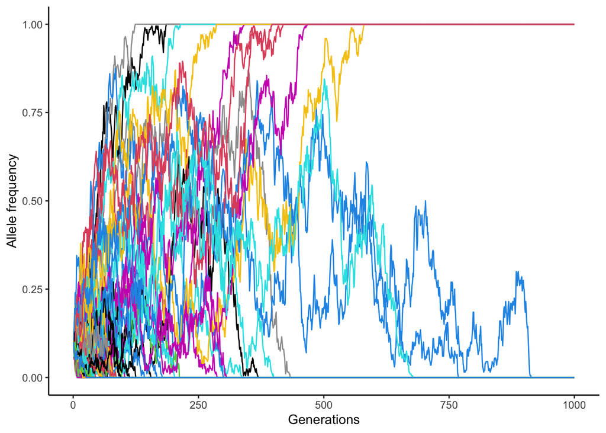

```r
# Let's just use the first 100 SNP's since it shouldn't matter which ones we pick.
toPlot <- driftResults[,1:100] %>%
  as.data.frame() %>%
  mutate(gen = 1:nrow(.)) %>%
  pivot_longer(cols = -gen, names_to = "whichSNP", values_to = "freq")

toPlot %>%
  filter(gen <= 1000) %>% # let's limit it to just the first 1000 generations.
  ggplot(aes(x = gen, y = freq, col = whichSNP))+
  geom_line()+
  theme_classic()+
  theme(legend.position = "none")+
  scale_color_manual(values = rep(palette(), 15))+
  ylab("Allele frequency")+
  xlab("Generations")
```

Repeat the simulation, but this time set `p`=0.6. e) How many of the 1000 SNP are at frequency 0 at the end of the simulation (in generation 10000)?

```r
set.seed(3)
driftResults2 <- driftFunction(N = 100, L = 1000, t = 10000, p = 0.6)
ngone2 <- sum(tail(driftResults2, 1) == 0)
```

397 of the 1000 SNPs are at frequency 0 at the end of the simulation (in generation 10000)

5. How many are at frequency 1?

```r
nfixed2 <- sum(tail(driftResults2, 1) == 1)
```

6. Does this value agree with the theoretical prediction for the probability of fixation of a neutral allele?

*Yes, this agrees with theory. If the initial frequency of the allele is 0.6, then its probability of going to fixation is also 0.6, so we would expect roughly 600 out of 1000 neutral alleles to go to fixation. 603 is very close to 600, and if we ran this simulation many times, we’d see the values cluster around 600.*

### EXERCISE 4.

Let’s look at the effect of the population size on patterns of genetic drift.

Repeat the simulation, but this time, set `N`=10, 500 and 1000. Keep the other parameters the same (`p`=0.1; `L`=1000; `t`=10000). Again, `N` is the number of diploids.

1. Make plots similar to the one shown above, but for all 4 populations sizes (`N`={10, 100, 500, 1000}). Plot all 4 plots on the same page so you can compare them.

```r
set.seed(4)
results10 <- driftFunction(N = 10, L = 1000, t = 10000, p = 0.1)
results100 <- driftFunction(N = 100, L = 1000, t = 10000, p = 0.1)
results500 <- driftFunction(N = 500, L = 1000, t = 10000, p = 0.1)
results1000 <- driftFunction(N = 1000, L = 1000, t = 10000, p = 0.1)
```

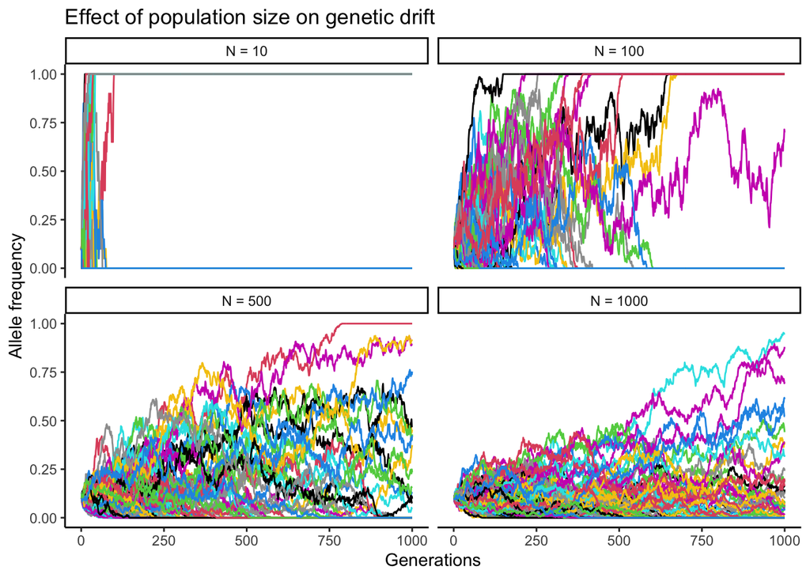

```r
# Put all the results in a list so we can work with them
results <- list("10" = results10, "100" = results100,
                "500" = results500, "1000" = results1000)

# Subset each of the results and reformat it for plotting
resultsSubset <- lapply(results, function(x){ # reformat each of the data frames
  x[,1:100] %>%
    as.data.frame() %>%
    mutate(gen = 1:nrow(.)) %>%
    filter(gen <= 1000) %>%
    pivot_longer(cols = -gen, names_to = "whichSNP", values_to = "freq")
}) %>%
  map2(.x = ., .y = names(.), # add identifier for N
       .f = function(.x, .y){
         .x %>%
           mutate(n = paste0("N = ", .y)) # make facet labels
       }) %>%
  data.table::rbindlist() %>% # bind all of them together
  as.data.frame() %>%
  mutate(n = fct_relevel(n, "N = 10", "N = 100", "N = 500", "N = 1000"))

# Make a plot, facetted by N
resultsSubset %>%
  ggplot(aes(x = gen, y = freq, col = whichSNP))+
  facet_wrap(~n) + # facet by n
  geom_line() +
  theme_classic()+
  theme(legend.position = "none")+ # legend would be meaningless here because these are just random SNPs
  scale_color_manual(values = rep(palette(), 15))+ # let's just use the basic colors repeated over and over again
  # add some nice labels
  ylab("Allele frequency")+
  xlab("Generations")+
  # add a title
  ggtitle("Effect of population size on genetic drift")
```

2. Based on examination of the plots, how does the population size affect allele frequency change?

*By examining the plots, I can see that increasing the population size increases the length of time that the alleles persist in the population. At a very small population size, almost all the alleles have either gone to fixation or died out after about 100 generations. But when N increases to 100, one allele persists almost all the way through the 1000th generation, and when N is 1000, no alleles have gone to fixation and it seems that few have died out either.*

3. For each population size, in what proportion of simulation replicates did the derived allele become fixed by the end of the simulation?

```r
props <- lapply(results, function(x){mean(x[nrow(x),] == 1)}) # calculate proportion fixed for each one
```

For N = 10, the proportion of alleles that went to fixation was 0.099 For N = 100, the proportion of alleles that went to fixation was 0.096 For N = 500, the proportion of alleles that went to fixation was 0.102 For N = 1000, the proportion of alleles that went to fixation was 0.086

4. How is this probability affected by the population size?

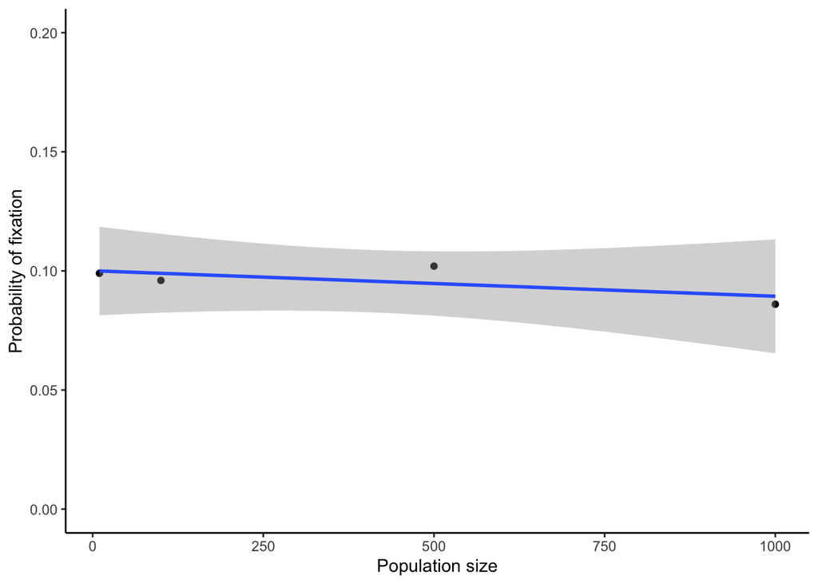

```r
propsdf <- data.frame(n = as.numeric(names(props)),
                      propFixed = unlist(props))

# Plot the relationship
propsdf %>%
  ggplot(aes(x = n, y = propFixed))+
  geom_point()+
  ylim(0, 0.2)+
  geom_smooth(method = "lm")+
  theme_classic()+
  ylab("Probability of fixation")+
  xlab("Population size")
```

*There is no significant relationship between the population size and the probability that an allele goes to fixation.*

5. How does this probability of fixation estimated from the simulations match with the theoretical prediction?

*This makes sense–the theoretical prediction for neutral alleles under genetic drift says that the probability of fixation depends only on their initial frequency in the population. So changing the population size should not affect the probability of fixation.* # XXX how do we account for using the population size in the rbinom() function, then?

### EXERCISE 5.

Based on your simulations from the previous questions, in which population size (e.g. N={10, 100, 500, 1000}) would you expect an allele to go to fixation the fastest, given that it goes to fixation?

*I would expect an allele to go to fixation the fastest in the N = 10 population, given that it goes to fixation. As the graphs above show, when N = 10, all alleles either go to fixation or die out very rapidly.*

Why?